# Regresja i analiza wariancji - Sprawozdanie 3

Metody klasyfikacji

Lidia Furgał, Karolina Majdak

Politechnika Krakowska

# Analiza Rozpoznawania Banknotów za pomocą Regresji Logistycznej

W pliku `banknotes.csv` znajdują się dane dotyczące obrazów banknotów, które zostały uzyskane poprzez transformację falową (wavelet transform) zastosowaną do obrazów w skali szarości o wymiarach 400x400 pikseli. Po przetworzeniu danych, wyodrębniono cztery kluczowe charakterystyki liczbowe: wariancję, skośność, kurtozę oraz entropię. Celem niniejszej analizy jest zbudowanie modelu regresji logistycznej, który pozwoli na efektywne odróżnienie banknotów prawdziwych od fałszywych.

Aby przeprowadzić tę analizę, rozpoczniemy od zaimportowania niezbędnych bibliotek oraz wczytania danych z pliku `banknotes.csv`. Następnie zdefiniujemy zmienne niezależne, które będą obejmować wspomniane wcześniej cechy, oraz zmienną zależną, wskazującą na prawdziwość banknotu (**0 - prawdziwy**, **1 - fałszywy**).

Aby ocenić skuteczność modelu, skonstruujemy macierz pomyłek, która ilustruje, jak model radzi sobie z klasyfikacją poszczególnych klas. Zbadamy także metryki, takie jak dokładność, precyzja, czułość, które pozwolą na wszechstronną ocenę wydajności modelu.

Na koniec wyrysujemy krzywą **ROC** oraz obliczymy wartość **AUC** (Area Under the Curve), co dostarczy informacji o ogólnej zdolności modelu do rozróżniania prawdziwych banknotów od fałszywych. Analiza wyników, w tym wartości **AUC**, pozwoli na lepsze zrozumienie efektywności modelu oraz jego przydatności w praktycznych zastosowaniach.

```r
bank <- readr::read_csv('banknote.csv', col_names = FALSE, show_col_types = FALSE)
head(bank)
```

| X1 | X2 | X3 | X4 | X5 |
| --- | --- | --- | --- | --- |
| 3.62160 | 8.6661 | -2.8073 | -0.44699 | 0 |
| 4.54590 | 8.1674 | -2.4586 | -1.46210 | 0 |
| 3.86600 | -2.6383 | 1.9242 | 0.10645 | 0 |
| 3.45660 | 9.5228 | -4.0112 | -3.59440 | 0 |
| 0.32924 | -4.4552 | 4.5718 | -0.98880 | 0 |
| 4.36840 | 9.6718 | -3.9606 | -3.16250 | 0 |

Przystąpmy do konstrukcji modelu regresji logistycznej, w którym zmienną objaśnianą będzie dychotomiczna zmienna **X5**. Predyktorami w tym modelu staną się pozostałe zmienne zawarte w ramce danych. Po skonstruowaniu modelu zaprezentujmy jego podsumowanie, aby ocenić wyniki oraz znaczenie poszczególnych zmiennych w kontekście przewidywania wyniku.

```r
logistic_regression <- glm(X5 ~ X1+X2+X3+X4, data = bank, family = 'binomial')
summary(logistic_regression)
```

```
##
## Call:
## glm(formula = X5 ~ X1 + X2 + X3 + X4, family = "binomial", data = bank)
##
## Coefficients:
##             Estimate Std. Error z value Pr(>|z|)
## (Intercept)   7.3218     1.5589   4.697 2.64e-06 ***
## X1           -7.8593     1.7383  -4.521 6.15e-06 ***
## X2           -4.1910     0.9041  -4.635 3.56e-06 ***
## X3           -5.2874     1.1612  -4.553 5.28e-06 ***
## X4           -0.6053     0.3307  -1.830   0.0672 .
## ---
## Signif. codes:  0 '***' 0.001 '**' 0.01 '*' 0.05 '.' 0.1 ' ' 1
##
## (Dispersion parameter for binomial family taken to be 1)
##
##     Null deviance: 1885.122  on 1371  degrees of freedom
## Residual deviance:   49.891  on 1367  degrees of freedom
## AIC: 59.891
##
## Number of Fisher Scoring iterations: 12
```

Aby ocenić jakość klasyfikacji, stwórzmy macierz pomyłek, która ilustruje, jak model klasyfikuje obserwacje. Następnie wizualizujemy tę macierz za pomocą funkcji *ggplot*.

```r
fmpreds <- predict(logistic_regression, bank, type = 'response')
fmpreds_classes <- ifelse(fmpreds > 0.5, 1, 0)
```

```r
fm_cm <- caret::confusionMatrix(factor(fmpreds_classes), factor(bank$X5))
fm_confusion_matrix <- fm_cm$table
fm_cm
```

```
## Confusion Matrix and Statistics
##
##           Reference
## Prediction   0   1
##          0 757   6
##          1   5 604
##
##                Accuracy : 0.992
##                  95% CI : (0.9857, 0.996)
##     No Information Rate : 0.5554
##     P-Value [Acc > NIR] : <2e-16
##
##                   Kappa : 0.9838
##
##  Mcnemar's Test P-Value : 1
##
##             Sensitivity : 0.9934
##             Specificity : 0.9902
##          Pos Pred Value : 0.9921
##          Neg Pred Value : 0.9918
##              Prevalence : 0.5554
##          Detection Rate : 0.5517
##    Detection Prevalence : 0.5561
##       Balanced Accuracy : 0.9918
##
##        'Positive' Class : 0
##
```

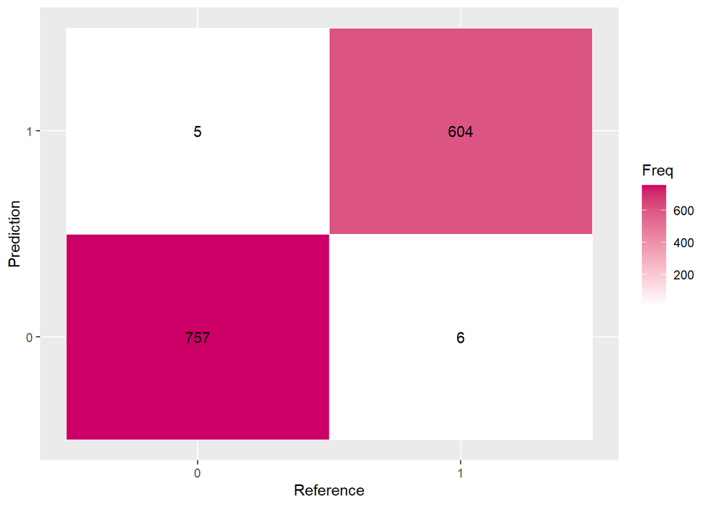

```r
ggplot(as.data.frame(fm_confusion_matrix), aes(x = Reference, y = Prediction)) +
  geom_tile(aes(fill = Freq), colour = 'white') + scale_fill_gradient(low = 'white', high = '#cc0066') +
  geom_text(aes(x = Reference, y = Prediction, label = Freq))
```

Przyjmijmy następujące oznaczenia: $0$ oznacza banknot prawdziwy, a $1$ banknot fałszywy. Model regresji logistycznej skutecznie zidentyfikował $757$ banknotów prawdziwych oraz $604$ banknoty fałszywe. Warto zauważyć, że $6$ banknotów fałszywych zostało błędnie zaklasyfikowanych jako banknoty prawdziwe, natomiast $5$ banknotów prawdziwych zostało niewłaściwie oznaczonych jako fałszywe.

Takie wyniki wskazują, że model jest w stanie poprawnie klasyfikować większość banknotów, jednak pojawiają się również błędy klasyfikacji, które mogą wpływać na jego ogólną skuteczność.

Zinterpretujmy teraz charakterystyki liczbowe modelu regresji logistycznej.

- **Dokładność** (*accuracy*) modelu wynosi $0,992$, co oznacza, że model poprawnie klasyfikuje banknoty prawdziwe i fałszywe w $99,20\%$ przypadków.
- **Czułość** (*sensitivity*) modelu osiąga wartość $0,9934$, co wskazuje, że $99,34\%$ prawdziwych banknotów zostało poprawnie sklasyfikowanych jako prawdziwe.
- **Swoistość** (*specificity*) wynosi natomiast $0,9902$, co oznacza, że $99,02\%$ banknotów fałszywych zostało prawidłowo zidentyfikowanych jako fałszywe.

Te wyniki sugerują, że model regresji logistycznej charakteryzuje się wysoką skutecznością w klasyfikacji banknotów, zarówno prawdziwych, jak i fałszywych.

Z powyższych charakterystyk liczbowych wynika, że transformaty falowe skutecznie pozwalają na rozróżnienie banknotów prawdziwych od fałszywych.

Aby zweryfikować efektywność naszego klasyfikatora, skonstruujmy krzywą **ROC**. Krzywa ta pozwoli nam ocenić, jak dobrze model klasyfikuje dane, zmieniając próg decyzyjny. Następnie obliczymy charakterystykę liczbową **AUC** (Area Under the Curve), która reprezentuje pole pod krzywą. **AUC** dostarcza informacji o ogólnej wydajności modelu – im wyższa wartość **AUC**, tym lepsza zdolność klasyfikacyjna modelu.

Przygotujmy dane do wyrysowania krzywej **ROC** oraz obliczmy wartość **AUC**.

```r
fmroc <- pROC::roc(response = bank$X5, predictor = fmpreds)
```

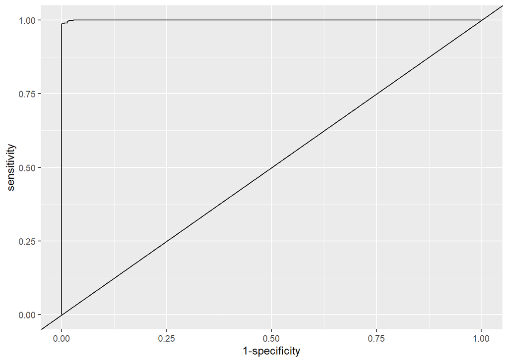

```r
pROC::ggroc(fmroc, legacy.axes = TRUE) + geom_abline(slope = 1, intercept = 0)
```

```r
fmroc$auc
```

```
## Area under the curve: 0.9998
```

Wartość pola pod krzywą **ROC** wynosząca $0,9998$, bliska $1$, sugeruje, że skonstruowany model regresji logistycznej skutecznie rozróżnia banknoty prawdziwe od fałszywych. Taki wynik potwierdza wysoką jakość modelu, wskazując, że jest on w stanie bardzo precyzyjnie klasyfikować banknoty w obie kategorie.